# Analysis no special features

group 3

7/19/2019

# Instructions

## Required R packages

- `tidyverse` (or `ggplot2`, `dplyr`, `purrr`, `tibble`)
- `brms`
- `devtools` (for installing `faintr`)
- `rstan`
- `faintr` (install with `devtools`)

Load the required packages and set a seed for the random number generator.

```r
library(tidyverse)
library(rstan)
# set cores to use to the total number of cores (minimally 4)
options(mc.cores = max(parallel::detectCores(), 4))
# save a compiled version of the Stan model file
rstan_options(auto_write = TRUE)
library(brms)
# install faintr with devtools::install_github('michael-franke/bayes_mixed_regression_tutorial/faintr', build_vignettes = TRUE))
library(faintr)
set.seed(123)
```

## Step 1. Read the data and take a glimpse of it.

```r
data_raw <- read_csv("results_71_givemegestalt_group3_group3.csv")
glimpse(data_raw)
```

```
## Observations: 12,078
## Variables: 24
## $ submission_id  <dbl> 566, 566, 566, 566, 566, 566, 566, 566, 566, 56...
## $ QUD            <lgl> NA, NA, NA, NA, NA, NA, NA, NA, NA, NA, NA, NA,...
## $ RT             <dbl> 57807, 13595, 14410, 4927, 4493, 2380, 2907, 66...
## $ age            <dbl> 20, 20, 20, 20, 20, 20, 20, 20, 20, 20, 20, 20,...
## $ comments       <chr> NA, NA, NA, NA, NA, NA, NA, NA, NA, NA, NA, NA,...
## $ endTime        <dbl> 1.562946e+12, 1.562946e+12, 1.562946e+12, 1.562...
## $ experiment_id  <dbl> 71, 71, 71, 71, 71, 71, 71, 71, 71, 71, 71, 71,...
## $ fileID         <dbl> NA, NA, 26, 3, 11, 4, 22, 33, 17, 60, 23, 59, 5...
## $ gender         <chr> "female", "female", "female", "female", "female...
## $ is_expert      <chr> "No", "No", "No", "No", "No", "No", "No", "No",...
## $ min_chars      <dbl> 0, NA, NA, NA, NA, NA, NA, NA, NA, NA, NA, NA, ...
## $ option1        <chr> NA, "Yes", NA, NA, NA, NA, NA, NA, NA, NA, NA, ...
## $ option2        <chr> NA, "No", NA, NA, NA, NA, NA, NA, NA, NA, NA, N...
## $ optionLeft     <chr> NA, NA, "not at all", "not at all", "not at all...
## $ optionRight    <chr> NA, NA, "very much", "very much", "very much", ...
## $ picture        <chr> "images/snellen/snellen.png", NA, "images/stimu...
## $ question       <chr> "Which row is the last one where you can recogn...
## $ response       <chr> "9", "No", "6", "5", "3", "3", "1", "5", "4", "...
## $ snellen_result <dbl> 9, 9, 9, 9, 9, 9, 9, 9, 9, 9, 9, 9, 9, 9, 9, 9,...
## $ startDate      <chr> "Fri Jul 12 2019 17:34:17 GMT+0200 (Mitteleurop...
## $ startTime      <dbl> 1.562946e+12, 1.562946e+12, 1.562946e+12, 1.562...
## $ timeSpent      <dbl> 11.90795, 11.90795, 11.90795, 11.90795, 11.9079...
## $ trial_name     <chr> "test_snellen", "b0_expert", "b1_exp", "b1_exp"...
## $ trial_number   <dbl> 1, 1, 1, 2, 3, 4, 5, 6, 7, 8, 9, 10, 11, 12, 13...
```

Step 2. Select only the columns of interest and filter trials that are not interesting for the calculations. Change data type of the responses to double and submission_id to factor. Detect outliers. —

```r
data_selection <- select(data_raw, submission_id, snellen_result, is_expert, age, gender, trial_name, trial_number, fileID, response, RT, timeSpent, comments)
data_filtered <- filter(data_selection, trial_name != "test_snellen", trial_name != "b0_expert")
data_mut <- mutate(data_filtered, response = as.double(response), submission_id = factor(submission_id))
show(data_selection)
```

```
## # A tibble: 12,078 x 12
##    submission_id snellen_result is_expert   age gender trial_name
##            <dbl>          <dbl> <chr>     <dbl> <chr>  <chr>
##  1           566              9 No           20 female test_snel~
##  2           566              9 No           20 female b0_expert
##  3           566              9 No           20 female b1_exp
##  4           566              9 No           20 female b1_exp
##  5           566              9 No           20 female b1_exp
##  6           566              9 No           20 female b1_exp
##  7           566              9 No           20 female b1_exp
##  8           566              9 No           20 female b1_exp
##  9           566              9 No           20 female b1_exp
## 10           566              9 No           20 female b1_exp
## # ... with 12,068 more rows, and 6 more variables: trial_number <dbl>,
## #   fileID <dbl>, response <chr>, RT <dbl>, timeSpent <dbl>,
## #   comments <chr>
```

```r
show(data_filtered)
```

```
## # A tibble: 11,880 x 12
##    submission_id snellen_result is_expert   age gender trial_name
##            <dbl>          <dbl> <chr>     <dbl> <chr>  <chr>
##  1           566              9 No           20 female b1_exp
##  2           566              9 No           20 female b1_exp
##  3           566              9 No           20 female b1_exp
##  4           566              9 No           20 female b1_exp
##  5           566              9 No           20 female b1_exp
##  6           566              9 No           20 female b1_exp
##  7           566              9 No           20 female b1_exp
##  8           566              9 No           20 female b1_exp
##  9           566              9 No           20 female b1_exp
## 10           566              9 No           20 female b1_exp
## # ... with 11,870 more rows, and 6 more variables: trial_number <dbl>,
## #   fileID <dbl>, response <chr>, RT <dbl>, timeSpent <dbl>,
## #   comments <chr>
```

```r
show(data_mut)
```

```
## # A tibble: 11,880 x 12
##    submission_id snellen_result is_expert   age gender trial_name
##    <fct>                  <dbl> <chr>     <dbl> <chr>  <chr>
##  1 566                        9 No           20 female b1_exp
##  2 566                        9 No           20 female b1_exp
##  3 566                        9 No           20 female b1_exp
##  4 566                        9 No           20 female b1_exp
##  5 566                        9 No           20 female b1_exp
##  6 566                        9 No           20 female b1_exp
##  7 566                        9 No           20 female b1_exp
##  8 566                        9 No           20 female b1_exp
##  9 566                        9 No           20 female b1_exp
## 10 566                        9 No           20 female b1_exp
## # ... with 11,870 more rows, and 6 more variables: trial_number <dbl>,
## #   fileID <dbl>, response <dbl>, RT <dbl>, timeSpent <dbl>,
## #   comments <chr>
```

```r
# 3 participants only rated "1" in both blocks, one participant only rated "7", one gave a invalid input for the Snellen test, we exclude them:
data_clean <- filter(data_mut, submission_id != 607, submission_id != 736, submission_id != 475, submission_id != 480, submission_id != 726)
show(data_clean)
```

```
## # A tibble: 11,280 x 12
##    submission_id snellen_result is_expert   age gender trial_name
##    <fct>                  <dbl> <chr>     <dbl> <chr>  <chr>
##  1 566                        9 No           20 female b1_exp
##  2 566                        9 No           20 female b1_exp
##  3 566                        9 No           20 female b1_exp
##  4 566                        9 No           20 female b1_exp
##  5 566                        9 No           20 female b1_exp
##  6 566                        9 No           20 female b1_exp
##  7 566                        9 No           20 female b1_exp
##  8 566                        9 No           20 female b1_exp
##  9 566                        9 No           20 female b1_exp
## 10 566                        9 No           20 female b1_exp
## # ... with 11,270 more rows, and 6 more variables: trial_number <dbl>,
## #   fileID <dbl>, response <dbl>, RT <dbl>, timeSpent <dbl>,
## #   comments <chr>
```

## Demografics

```r
data_rawdemografics <- select(data_clean, submission_id, age, gender, is_expert, snellen_result, comments)
data_demografics <- dplyr::distinct(group_by(data_rawdemografics, submission_id))
show(data_demografics[order(data_demografics$submission_id),])
```

```
## # A tibble: 94 x 6
## # Groups:   submission_id [94]
##    submission_id   age gender is_expert snellen_result comments
##    <fct>         <dbl> <chr>  <chr>              <dbl> <chr>
##  1 458              51 male   Yes                    9 <NA>
##  2 459              20 female Yes                    9 <NA>
##  3 460              18 female No                     9 <NA>
##  4 461              63 male   No                    10 <NA>
##  5 462              29 female No                     9 <NA>
##  6 463              56 female No                     7 <NA>
##  7 464              21 female No                    10 <NA>
##  8 465              21 female No                     9 <NA>
##  9 466              19 female No                     8 <NA>
## 10 467              23 male   No                    10 <NA>
## # ... with 84 more rows
```

Total number of participents:

```r
length(unique(data_clean$submission_id))
```

```
## [1] 94
```

Detecting the gender data provided and their count:

```r
data_gender_male <- filter(data_clean,gender == "male")
data_gender_female <- filter(data_clean,gender == "female")
data_gender_diverse <- filter(data_clean,gender == "divers")
length(data_gender_male$gender)/120
```

```
## [1] 33
```

```r
length(data_gender_female$gender)/120
```

```
## [1] 57
```

```r
length(data_gender_diverse$gender)/120
```

```
## [1] 2
```

```r
sum(is.na(data_clean$gender))/120 # counting how many NA are there.
```

```
## [1] 2
```

Data set according to age :

```r
data_age_below_20 <- filter(data_clean,age <= 19)
data_age_20_40<-filter(data_clean,age>=20&age<=40)
data_age_ab_40 <- filter(data_clean,age > 40)
#divide by 122 beacuse there are 122 entries per person
length(data_age_below_20$age)/120
```

```
## [1] 14
```

```r
length(data_age_20_40$age)/120
```

```
## [1] 69
```

```r
length(data_age_ab_40$age)/120
```

```
## [1] 10
```

```r
sum(is.na(data_clean$age))/120
```

```
## [1] 1
```

Step 3. Filter participants with special features as being an expert or having failed the vision test. Split data according to trial (b1: Liking, b2: Detactability). —

```r
# Data without special groups
data_normal <- filter(data_clean, is_expert == "No", snellen_result > 6)
b1_normal <- filter(data_normal, trial_name == "b1_exp")
b2_normal <- filter(data_normal, trial_name == "b2_exp")
show(b1_normal)
```

```
## # A tibble: 4,980 x 12
##    submission_id snellen_result is_expert   age gender trial_name
##    <fct>                  <dbl> <chr>     <dbl> <chr>  <chr>
##  1 566                        9 No           20 female b1_exp
##  2 566                        9 No           20 female b1_exp
##  3 566                        9 No           20 female b1_exp
##  4 566                        9 No           20 female b1_exp
##  5 566                        9 No           20 female b1_exp
##  6 566                        9 No           20 female b1_exp
##  7 566                        9 No           20 female b1_exp
##  8 566                        9 No           20 female b1_exp
##  9 566                        9 No           20 female b1_exp
## 10 566                        9 No           20 female b1_exp
## # ... with 4,970 more rows, and 6 more variables: trial_number <dbl>,
## #   fileID <dbl>, response <dbl>, RT <dbl>, timeSpent <dbl>,
## #   comments <chr>
```

```r
show(b2_normal)
```

```
## # A tibble: 4,980 x 12
##    submission_id snellen_result is_expert   age gender trial_name
##    <fct>                  <dbl> <chr>     <dbl> <chr>  <chr>
##  1 566                        9 No           20 female b2_exp
##  2 566                        9 No           20 female b2_exp
##  3 566                        9 No           20 female b2_exp
##  4 566                        9 No           20 female b2_exp
##  5 566                        9 No           20 female b2_exp
##  6 566                        9 No           20 female b2_exp
##  7 566                        9 No           20 female b2_exp
##  8 566                        9 No           20 female b2_exp
##  9 566                        9 No           20 female b2_exp
## 10 566                        9 No           20 female b2_exp
## # ... with 4,970 more rows, and 6 more variables: trial_number <dbl>,
## #   fileID <dbl>, response <dbl>, RT <dbl>, timeSpent <dbl>,
## #   comments <chr>
```

Step 4. Average data. Generate table with needed non-aggregated data in useful format.

Data of participants without special features (snellen failed, expert)

```r
# Averaged data:
b1_normal_mean <- group_by(b1_normal, fileID) %>% summarise(mean_Like_normal = mean(response))
b2_normal_mean <- group_by(b2_normal, fileID) %>% summarise(mean_Detect_normal = mean(response))
show(b1_normal_mean)
```

```
## # A tibble: 60 x 2
##    fileID mean_Like_normal
##     <dbl>            <dbl>
##  1      1             3.54
##  2      2             4
##  3      3             4.13
##  4      4             2.96
##  5      5             3.45
##  6      6             3.93
##  7      7             3.47
##  8      8             3.45
##  9      9             3.42
## 10     10             3.49
## # ... with 50 more rows
```

```r
show(b2_normal_mean)
```

```
## # A tibble: 60 x 2
##    fileID mean_Detect_normal
##     <dbl>              <dbl>
##  1      1               3.27
##  2      2               3.95
##  3      3               3.08
##  4      4               2.99
##  5      5               3.14
##  6      6               3.96
##  7      7               3.86
##  8      8               3.10
##  9      9               3.36
## 10     10               3.65
## # ... with 50 more rows
```

```r
final_normal_mean <- merge(x = b2_normal_mean, y = b1_normal_mean, by = "fileID")
show(final_normal_mean)
```

```
##    fileID mean_Detect_normal mean_Like_normal
## 1       1           3.265060         3.542169
## 2       2           3.951807         4.000000
## 3       3           3.084337         4.132530
## 4       4           2.987952         2.963855
## 5       5           3.144578         3.445783
## 6       6           3.963855         3.927711
## 7       7           3.855422         3.469880
## 8       8           3.096386         3.445783
## 9       9           3.361446         3.421687
## 10     10           3.650602         3.493976
## 11     11           3.060241         3.024096
## 12     12           4.060241         3.951807
## 13     13           3.361446         3.204819
## 14     14           3.698795         3.192771
```

[output cut: 46 more lines]

```r
# Non-average data:
b1_normal_mutated <- mutate(b1_normal, liking_normal = response, RT_liking = RT)
b2_normal_mutated <- mutate(b2_normal, detectability_normal = response, RT_detectability = RT)
b1_normal_selected <- select(b1_normal_mutated, fileID, submission_id, age, snellen_result, timeSpent, liking_normal, RT_liking)
b2_normal_selected <- select(b2_normal_mutated, fileID, submission_id, age, snellen_result, timeSpent, detectability_normal, RT_detectability)
b1_normal_orderd <- b1_normal_selected[order(b1_normal_selected$fileID),]
b2_normal_orderd <- b2_normal_selected[order(b2_normal_selected$fileID),]
merged_normal_data <- b1_normal_orderd
merged_normal_data$detectability_normal <- b2_normal_orderd$detectability_normal
merged_normal_data$RT_detectability <- b2_normal_orderd$RT_detectability
show(b1_normal_selected)
```

```
## # A tibble: 4,980 x 7
##    fileID submission_id   age snellen_result timeSpent liking_normal
##     <dbl> <fct>         <dbl>          <dbl>     <dbl>         <dbl>
##  1     26 566              20              9      11.9             6
##  2      3 566              20              9      11.9             5
##  3     11 566              20              9      11.9             3
##  4      4 566              20              9      11.9             3
##  5     22 566              20              9      11.9             1
##  6     33 566              20              9      11.9             5
##  7     17 566              20              9      11.9             4
##  8     60 566              20              9      11.9             4
##  9     23 566              20              9      11.9             6
## 10     59 566              20              9      11.9             4
## # ... with 4,970 more rows, and 1 more variable: RT_liking <dbl>
```

```r
show(b2_normal_selected)
```

```
## # A tibble: 4,980 x 7
##    fileID submission_id   age snellen_result timeSpent detectability_n~
##     <dbl> <fct>         <dbl>          <dbl>     <dbl>            <dbl>
##  1     12 566              20              9      11.9                3
##  2      8 566              20              9      11.9                4
##  3      3 566              20              9      11.9                2
##  4     16 566              20              9      11.9                2
##  5     11 566              20              9      11.9                1
##  6     60 566              20              9      11.9                3
##  7     54 566              20              9      11.9                2
##  8      4 566              20              9      11.9                4
##  9      6 566              20              9      11.9                6
## 10     31 566              20              9      11.9                3
## # ... with 4,970 more rows, and 1 more variable: RT_detectability <dbl>
```

```r
show(b1_normal_orderd)
```

```
## # A tibble: 4,980 x 7
##    fileID submission_id   age snellen_result timeSpent liking_normal
##     <dbl> <fct>         <dbl>          <dbl>     <dbl>         <dbl>
##  1      1 566              20              9     11.9              4
##  2      1 553              19              8     24.0              3
##  3      1 627              28              9      6.65             3
##  4      1 681              21              9     10.7              3
##  5      1 735              20              7     14.3              3
##  6      1 745              NA              9     22.9              5
##  7      1 757              17             11      8.26             4
##  8      1 550              24             10     11.3              3
##  9      1 552              27              7     17.7              3
## 10      1 555              19              9     11.5              6
## # ... with 4,970 more rows, and 1 more variable: RT_liking <dbl>
```

```r
show(b2_normal_orderd)
```

```
## # A tibble: 4,980 x 7
##    fileID submission_id   age snellen_result timeSpent detectability_n~
##     <dbl> <fct>         <dbl>          <dbl>     <dbl>            <dbl>
##  1      1 566              20              9     11.9                 3
##  2      1 553              19              8     24.0                 5
##  3      1 627              28              9      6.65                3
##  4      1 681              21              9     10.7                 1
##  5      1 735              20              7     14.3                 3
##  6      1 745              NA              9     22.9                 4
##  7      1 757              17             11      8.26                1
##  8      1 550              24             10     11.3                 4
##  9      1 552              27              7     17.7                 2
## 10      1 555              19              9     11.5                 5
## # ... with 4,970 more rows, and 1 more variable: RT_detectability <dbl>
```

```r
show(merged_normal_data)
```

```
## # A tibble: 4,980 x 9
##    fileID submission_id   age snellen_result timeSpent liking_normal
##     <dbl> <fct>         <dbl>          <dbl>     <dbl>         <dbl>
##  1      1 566              20              9     11.9              4
##  2      1 553              19              8     24.0              3
##  3      1 627              28              9      6.65             3
##  4      1 681              21              9     10.7              3
##  5      1 735              20              7     14.3              3
##  6      1 745              NA              9     22.9              5
##  7      1 757              17             11      8.26             4
##  8      1 550              24             10     11.3              3
##  9      1 552              27              7     17.7              3
## 10      1 555              19              9     11.5              6
## # ... with 4,970 more rows, and 3 more variables: RT_liking <dbl>,
## #   detectability_normal <dbl>, RT_detectability <dbl>
```

```r
final_normal <- as_tibble(merged_normal_data)
show(final_normal)
```

```
## # A tibble: 4,980 x 9
##    fileID submission_id   age snellen_result timeSpent liking_normal
##     <dbl> <fct>         <dbl>          <dbl>     <dbl>         <dbl>
##  1      1 566              20              9     11.9              4
##  2      1 553              19              8     24.0              3
##  3      1 627              28              9      6.65             3
##  4      1 681              21              9     10.7              3
##  5      1 735              20              7     14.3              3
##  6      1 745              NA              9     22.9              5
##  7      1 757              17             11      8.26             4
##  8      1 550              24             10     11.3              3
##  9      1 552              27              7     17.7              3
## 10      1 555              19              9     11.5              6
## # ... with 4,970 more rows, and 3 more variables: RT_liking <dbl>,
## #   detectability_normal <dbl>, RT_detectability <dbl>
```

## Step 5.Test assumptions for linear regression.

Normality: participants without special features

```r
# Non-averaged data:
ks.test(b1_normal$response, pnorm)
```

```
##
##  One-sample Kolmogorov-Smirnov test
##
## data:  b1_normal$response
## D = 0.87705, p-value < 2.2e-16
## alternative hypothesis: two-sided
```

```r
ks.test(b2_normal$response, pnorm)
```

```
##
##  One-sample Kolmogorov-Smirnov test
##
## data:  b2_normal$response
## D = 0.88347, p-value < 2.2e-16
## alternative hypothesis: two-sided
```

```r
# Averaged data:
ks.test(b1_normal_mean$mean_Like_normal, pnorm)
```

```
##
##  One-sample Kolmogorov-Smirnov test
##
## data:  b1_normal_mean$mean_Like_normal
## D = 0.99823, p-value < 2.2e-16
## alternative hypothesis: two-sided
```

```r
ks.test(b2_normal_mean$mean_Detect_normal, pnorm)
```

```
##
##  One-sample Kolmogorov-Smirnov test
##
## data:  b2_normal_mean$mean_Detect_normal
## D = 0.99699, p-value < 2.2e-16
## alternative hypothesis: two-sided
```

Result: According to the Kolmogorov-Smirnov test the variables are not normal distributed. Hence, the normality assumption is not fullfiled. We will test the residual distribution in the next step to make sure that we can still use a linear regression.

Further assumptions: participants without special features

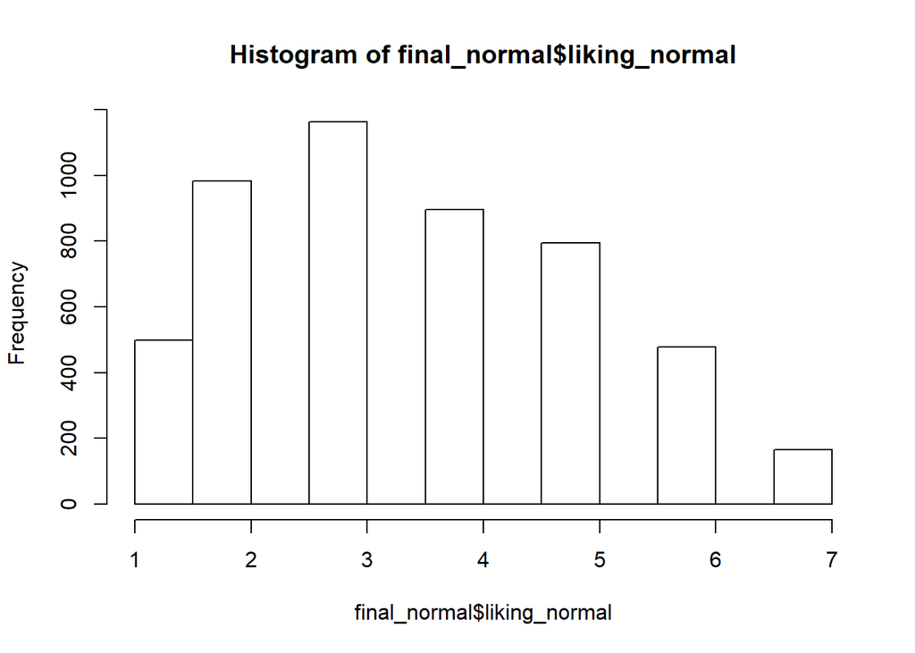

```r
# Non-averaged data:
hist(final_normal$liking_normal)
```

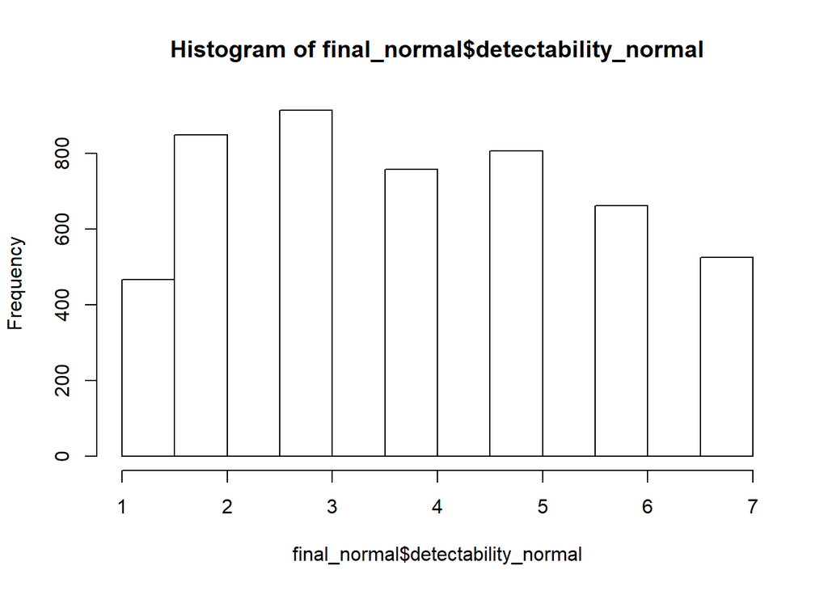

```r
hist(final_normal$detectability_normal)
```

```r
par(mfrow=c(2,2))
typeof(final_normal)
```

```
## [1] "list"
```

```r
mod_normal <- lm(final_normal$liking_normal ~ final_normal$detectability_normal, data=final_normal) #linear regression model
gvlma::gvlma(mod_normal) # further tests for assumtions
```

```
##
## Call:
## lm(formula = final_normal$liking_normal ~ final_normal$detectability_normal,
##     data = final_normal)
##
## Coefficients:
##                       (Intercept)  final_normal$detectability_normal
##                            2.4999                             0.2596
##
##
## ASSESSMENT OF THE LINEAR MODEL ASSUMPTIONS
## USING THE GLOBAL TEST ON 4 DEGREES-OF-FREEDOM:
## Level of Significance =  0.05
##
## Call:
##  gvlma::gvlma(x = mod_normal)
##
##                      Value   p-value                   Decision
## Global Stat        192.480 0.000e+00 Assumptions NOT satisfied!
## Skewness            33.079 8.851e-09 Assumptions NOT satisfied!
## Kurtosis            86.443 0.000e+00 Assumptions NOT satisfied!
## Link Function       71.675 0.000e+00 Assumptions NOT satisfied!
## Heteroscedasticity   1.283 2.574e-01    Assumptions acceptable.
```

```r
summary(mod_normal) # Show summary to check p-value
```

```
##
## Call:
## lm(formula = final_normal$liking_normal ~ final_normal$detectability_normal,
##     data = final_normal)
##
## Residuals:
##     Min      1Q  Median      3Q     Max
## -3.3174 -1.0578 -0.0578  1.2019  4.2404
##
## Coefficients:
##                                   Estimate Std. Error t value Pr(>|t|)
## (Intercept)                        2.49993    0.05117   48.85   <2e-16 ***
## final_normal$detectability_normal  0.25964    0.01178   22.04   <2e-16 ***
## ---
## Signif. codes:  0 '***' 0.001 '**' 0.01 '*' 0.05 '.' 0.1 ' ' 1
##
## Residual standard error: 1.521 on 4978 degrees of freedom
## Multiple R-squared:  0.08888,    Adjusted R-squared:  0.0887
## F-statistic: 485.6 on 1 and 4978 DF,  p-value: < 2.2e-16
```

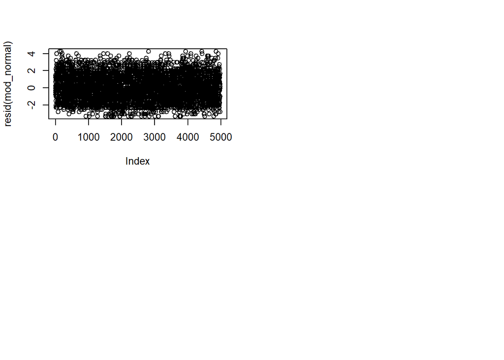

```r
plot(resid(mod_normal)) # Plot residuals to check if normality assumption is necessary
```

Result: For the non-averaged data, most of the assumptions necessary for linear-regression are not satisfied. Eventhough the violation of the normality assumtion is not important due to the huge sample size and the destribution of the residuals (https://iovs.arvojournals.org/article.aspx?articleid=2128171), we cannot use a linear regression for this data.

```r
# Averaged data:
show(b1_normal_mean)
```

```
## # A tibble: 60 x 2
##    fileID mean_Like_normal
##     <dbl>            <dbl>
##  1      1             3.54
##  2      2             4
##  3      3             4.13
##  4      4             2.96
##  5      5             3.45
##  6      6             3.93
##  7      7             3.47
##  8      8             3.45
##  9      9             3.42
## 10     10             3.49
## # ... with 50 more rows
```

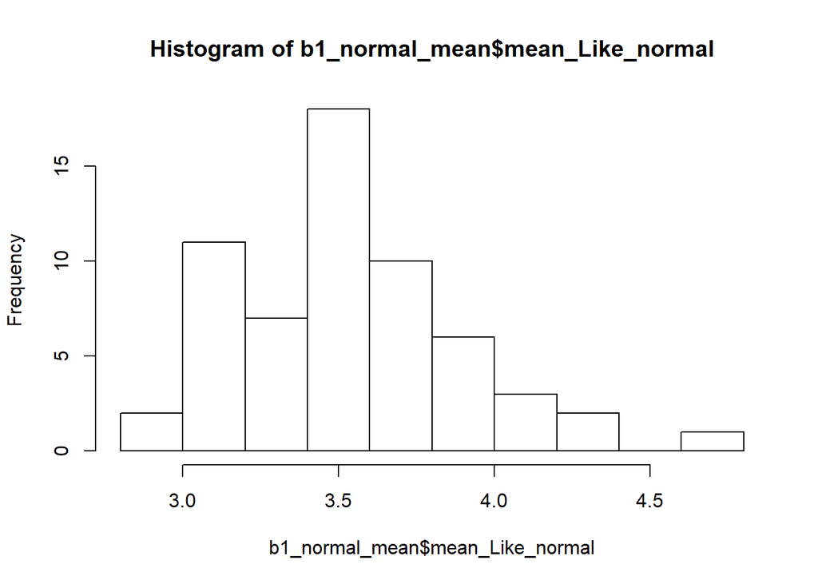

```r
hist(b1_normal_mean$mean_Like_normal)
```

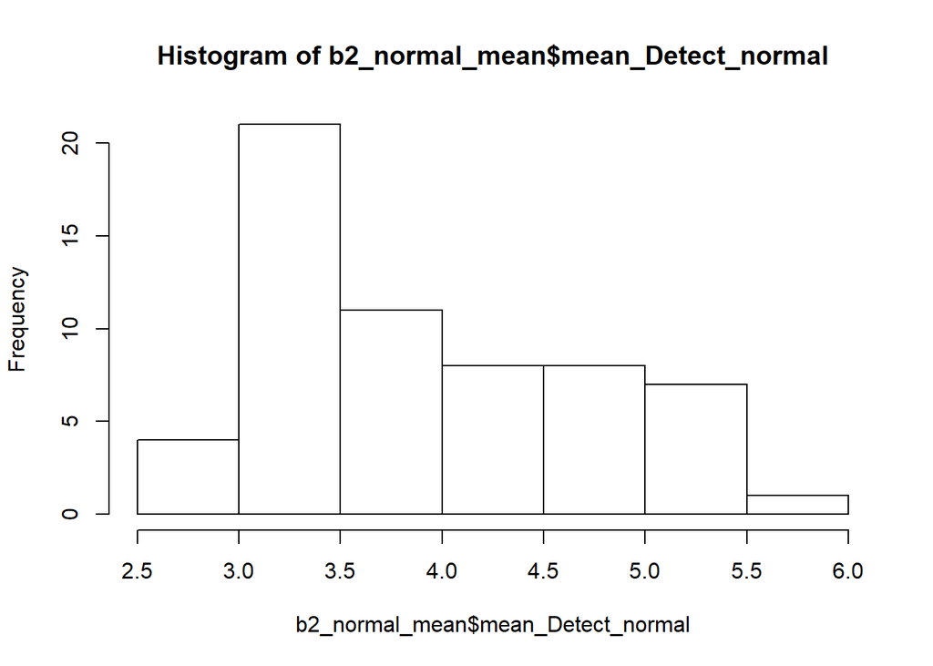

```r
hist(b2_normal_mean$mean_Detect_normal)
```

```r
par(mfrow=c(2,2))
typeof(b1_normal_mean)
```

```
## [1] "list"
```

```r
mod_mean_normal <- lm(b1_normal_mean$mean_Like_normal ~ b2_normal_mean$mean_Detect_normal, data=final_normal_mean) # linear regression model
gvlma::gvlma(mod_mean_normal) # further tests for assumtions
```

```
##
## Call:
## lm(formula = b1_normal_mean$mean_Like_normal ~ b2_normal_mean$mean_Detect_normal,
##     data = final_normal_mean)
##
## Coefficients:
##                       (Intercept)  b2_normal_mean$mean_Detect_normal
##                             2.428                              0.278
##
##
## ASSESSMENT OF THE LINEAR MODEL ASSUMPTIONS
## USING THE GLOBAL TEST ON 4 DEGREES-OF-FREEDOM:
## Level of Significance =  0.05
##
## Call:
##  gvlma::gvlma(x = mod_mean_normal)
##
##                     Value p-value                   Decision
## Global Stat        9.5633 0.04846 Assumptions NOT satisfied!
## Skewness           5.7708 0.01629 Assumptions NOT satisfied!
## Kurtosis           0.1978 0.65646    Assumptions acceptable.
## Link Function      0.8821 0.34763    Assumptions acceptable.
## Heteroscedasticity 2.7126 0.09956    Assumptions acceptable.
```

```r
summary(mod_mean_normal) # Show summary to check p-value
```

```
##
## Call:
## lm(formula = b1_normal_mean$mean_Like_normal ~ b2_normal_mean$mean_Detect_normal,
##     data = final_normal_mean)
##
## Residuals:
##     Min      1Q  Median      3Q     Max
## -0.4661 -0.2461 -0.0005  0.1473  0.8475
##
## Coefficients:
##                                   Estimate Std. Error t value Pr(>|t|)
## (Intercept)                        2.42769    0.19125  12.694  < 2e-16 ***
## b2_normal_mean$mean_Detect_normal  0.27798    0.04759   5.841 2.49e-07 ***
## ---
## Signif. codes:  0 '***' 0.001 '**' 0.01 '*' 0.05 '.' 0.1 ' ' 1
##
## Residual standard error: 0.2935 on 58 degrees of freedom
## Multiple R-squared:  0.3704, Adjusted R-squared:  0.3595
## F-statistic: 34.12 on 1 and 58 DF,  p-value: 2.487e-07
```

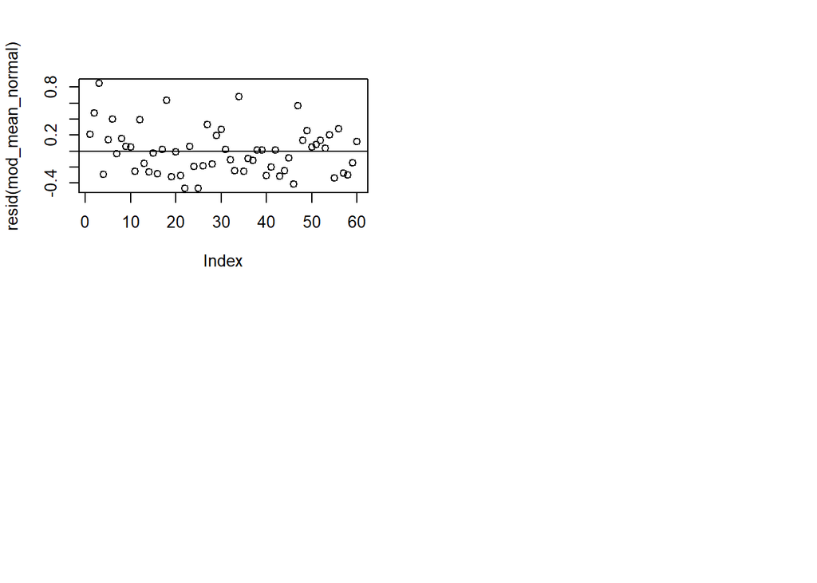

```r
plot(resid(mod_mean_normal)) # Plot residuals to check if normality assumption is necessary
abline(a=0,b=0)
```

Result: Most of the assumptions for linear regression are satisfied. The distribution of the residuals shows asymmetry along the zero line, but not enough to violate the normality assumption. The p-value shows us that our model is significant. The R-squared value is lower than in the original paper.

## Step 6. Make a plot of the averaged data.

Participants without special features:

```r
cor(b2_normal_mean$mean_Detect_normal, b1_normal_mean$mean_Like_normal)
```

```
## [1] 0.6085907
```

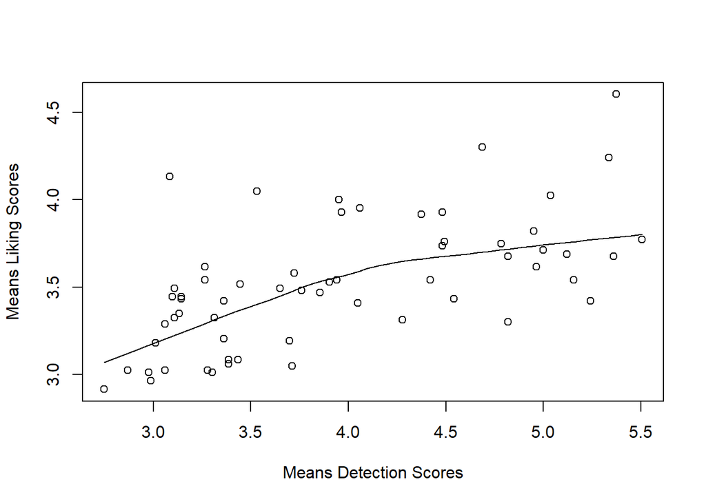

```r
scatter.smooth(y=b1_normal_mean$mean_Like_normal, x= b2_normal_mean$mean_Detect_normal, xlab = "Means Detection Scores", ylab = "Means Liking Scores")
```

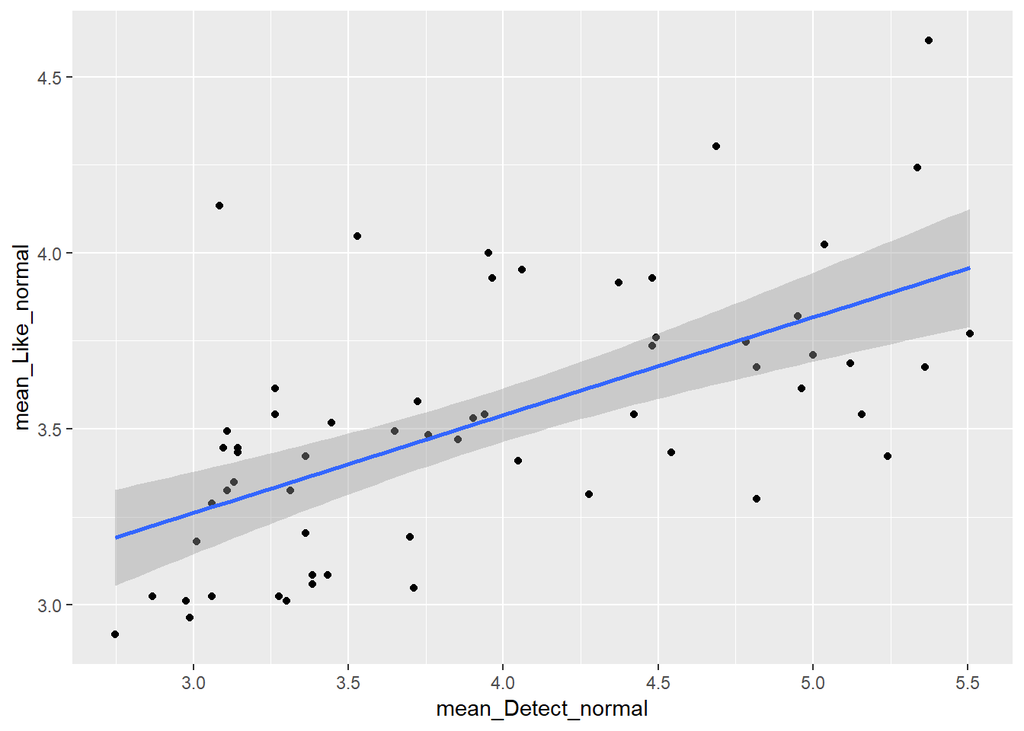

```r
ggplot(final_normal_mean, aes(x = mean_Detect_normal, y = mean_Like_normal)) + geom_point() + geom_smooth(method = "lm")
```

## Step 7. Run bayesian fixed-effects models

Averaged Data:

```r
brm_normal_gaussian <- brm(formula=mean_Like_normal ~ mean_Detect_normal, data=final_normal_mean, family = "gaussian")
summary(brm_normal_gaussian)
```

```
##  Family: gaussian
##   Links: mu = identity; sigma = identity
## Formula: mean_Like_normal ~ mean_Detect_normal
##    Data: final_normal_mean (Number of observations: 60)
## Samples: 4 chains, each with iter = 2000; warmup = 1000; thin = 1;
##          total post-warmup samples = 4000
##
## Population-Level Effects:
##                    Estimate Est.Error l-95% CI u-95% CI Eff.Sample Rhat
## Intercept              2.43      0.20     2.03     2.81       3677 1.00
## mean_Detect_normal     0.28      0.05     0.18     0.38       3700 1.00
##
## Family Specific Parameters:
##       Estimate Est.Error l-95% CI u-95% CI Eff.Sample Rhat
## sigma     0.30      0.03     0.25     0.36       3447 1.00
##
## Samples were drawn using sampling(NUTS). For each parameter, Eff.Sample
## is a crude measure of effective sample size, and Rhat is the potential
## scale reduction factor on split chains (at convergence, Rhat = 1).
```

Result: Positiv correltion, since estimate is 0.28.

Non-Averaged data: Cumulative family:

```r
final_normal_mutated <- mutate(final_normal, liking_normal = as.integer(liking_normal), detectability_normal = as.integer(detectability_normal))
show(final_normal_mutated)
```

```
## # A tibble: 4,980 x 9
##    fileID submission_id   age snellen_result timeSpent liking_normal
##     <dbl> <fct>         <dbl>          <dbl>     <dbl>         <int>
##  1      1 566              20              9     11.9              4
##  2      1 553              19              8     24.0              3
##  3      1 627              28              9      6.65             3
##  4      1 681              21              9     10.7              3
##  5      1 735              20              7     14.3              3
##  6      1 745              NA              9     22.9              5
##  7      1 757              17             11      8.26             4
##  8      1 550              24             10     11.3              3
##  9      1 552              27              7     17.7              3
## 10      1 555              19              9     11.5              6
## # ... with 4,970 more rows, and 3 more variables: RT_liking <dbl>,
## #   detectability_normal <int>, RT_detectability <dbl>
```

```r
brm_normal_cumulative <- brm(formula=liking_normal ~ mo(detectability_normal), data=final_normal_mutated, family = "cumulative")
summary(brm_normal_cumulative)
```

```
##  Family: cumulative
##   Links: mu = logit; disc = identity
## Formula: liking_normal ~ mo(detectability_normal)
##    Data: final_normal_mutated (Number of observations: 4980)
## Samples: 4 chains, each with iter = 2000; warmup = 1000; thin = 1;
##          total post-warmup samples = 4000
##
## Population-Level Effects:
##                        Estimate Est.Error l-95% CI u-95% CI Eff.Sample
## Intercept[1]              -0.93      0.09    -1.11    -0.75       2288
## Intercept[2]               0.51      0.09     0.33     0.69       2154
## Intercept[3]               1.58      0.09     1.39     1.76       2281
## Intercept[4]               2.41      0.10     2.22     2.60       2210
## Intercept[5]               3.46      0.10     3.26     3.66       2444
## Intercept[6]               4.96      0.12     4.72     5.19       2734
## modetectability_normal     0.34      0.02     0.30     0.38       2172
##                        Rhat
## Intercept[1]           1.00
## Intercept[2]           1.00
## Intercept[3]           1.00
## Intercept[4]           1.00
## Intercept[5]           1.00
## Intercept[6]           1.00
## modetectability_normal 1.00
##
## Simplex Parameters:
##                            Estimate Est.Error l-95% CI u-95% CI Eff.Sample
## modetectability_normal1[1]     0.41      0.04     0.32     0.48       2807
## modetectability_normal1[2]     0.23      0.04     0.14     0.31       3075
## modetectability_normal1[3]     0.22      0.04     0.14     0.30       4155
## modetectability_normal1[4]     0.09      0.04     0.03     0.17       3568
## modetectability_normal1[5]     0.03      0.02     0.00     0.08       4590
## modetectability_normal1[6]     0.03      0.02     0.00     0.09       3628
##                            Rhat
## modetectability_normal1[1] 1.00
## modetectability_normal1[2] 1.00
## modetectability_normal1[3] 1.00
## modetectability_normal1[4] 1.00
## modetectability_normal1[5] 1.00
## modetectability_normal1[6] 1.00
##
## Samples were drawn using sampling(NUTS). For each parameter, Eff.Sample
## is a crude measure of effective sample size, and Rhat is the potential
## scale reduction factor on split chains (at convergence, Rhat = 1).
```

Result: positive correlation, estimate is 0.34.

Cumulative family for mixed/random effects:

```r
brm_normal_mixed <- brm(formula=liking_normal ~ mo(detectability_normal) + (1|submission_id), data=final_normal_mutated, family = "cumulative")
summary(brm_normal_mixed)
```

```
##  Family: cumulative
##   Links: mu = logit; disc = identity
## Formula: liking_normal ~ mo(detectability_normal) + (1 | submission_id)
##    Data: final_normal_mutated (Number of observations: 4980)
## Samples: 4 chains, each with iter = 2000; warmup = 1000; thin = 1;
##          total post-warmup samples = 4000
##
## Group-Level Effects:
## ~submission_id (Number of levels: 83)
##               Estimate Est.Error l-95% CI u-95% CI Eff.Sample Rhat
## sd(Intercept)     1.11      0.09     0.95     1.32        658 1.00
##
## Population-Level Effects:
##                        Estimate Est.Error l-95% CI u-95% CI Eff.Sample
## Intercept[1]              -1.87      0.16    -2.18    -1.55        449
## Intercept[2]              -0.18      0.16    -0.48     0.13        423
## Intercept[3]               1.09      0.16     0.78     1.39        423
## Intercept[4]               2.06      0.16     1.75     2.37        428
## Intercept[5]               3.28      0.16     2.97     3.60        443
## Intercept[6]               4.96      0.18     4.61     5.33        518
## modetectability_normal     0.27      0.02     0.22     0.32       2598
##                        Rhat
## Intercept[1]           1.00
## Intercept[2]           1.00
## Intercept[3]           1.00
## Intercept[4]           1.00
## Intercept[5]           1.00
## Intercept[6]           1.00
## modetectability_normal 1.00
##
## Simplex Parameters:
##                            Estimate Est.Error l-95% CI u-95% CI Eff.Sample
## modetectability_normal1[1]     0.19      0.06     0.06     0.31       2870
## modetectability_normal1[2]     0.19      0.06     0.08     0.30       3158
## modetectability_normal1[3]     0.25      0.06     0.14     0.37       3676
## modetectability_normal1[4]     0.15      0.06     0.04     0.26       3756
## modetectability_normal1[5]     0.11      0.05     0.01     0.22       5387
## modetectability_normal1[6]     0.11      0.06     0.01     0.22       4585
##                            Rhat
## modetectability_normal1[1] 1.00
## modetectability_normal1[2] 1.00
## modetectability_normal1[3] 1.00
## modetectability_normal1[4] 1.00
## modetectability_normal1[5] 1.00
## modetectability_normal1[6] 1.00
##
## Samples were drawn using sampling(NUTS). For each parameter, Eff.Sample
## is a crude measure of effective sample size, and Rhat is the potential
## scale reduction factor on split chains (at convergence, Rhat = 1).
```

```r
brm_normal_mixed2 <- brm(formula=liking_normal ~ mo(detectability_normal) + (1|submission_id) + (1|fileID), data=final_normal_mutated, family = "cumulative")
summary(brm_normal_mixed2)
```

```
##  Family: cumulative
##   Links: mu = logit; disc = identity
## Formula: liking_normal ~ mo(detectability_normal) + (1 | submission_id) + (1 | fileID)
##    Data: final_normal_mutated (Number of observations: 4980)
## Samples: 4 chains, each with iter = 2000; warmup = 1000; thin = 1;
##          total post-warmup samples = 4000
##
## Group-Level Effects:
## ~fileID (Number of levels: 60)
##               Estimate Est.Error l-95% CI u-95% CI Eff.Sample Rhat
## sd(Intercept)     0.37      0.05     0.29     0.47       1329 1.00
##
## ~submission_id (Number of levels: 83)
##               Estimate Est.Error l-95% CI u-95% CI Eff.Sample Rhat
## sd(Intercept)     1.14      0.10     0.97     1.35        521 1.00
##
## Population-Level Effects:
##                        Estimate Est.Error l-95% CI u-95% CI Eff.Sample
## Intercept[1]              -1.97      0.18    -2.32    -1.63        408
## Intercept[2]              -0.26      0.17    -0.60     0.09        399
## Intercept[3]               1.04      0.17     0.69     1.38        406
## Intercept[4]               2.04      0.18     1.69     2.39        412
## Intercept[5]               3.29      0.18     2.94     3.65        428
## Intercept[6]               5.00      0.19     4.61     5.38        477
## modetectability_normal     0.25      0.03     0.20     0.29       2060
##                        Rhat
## Intercept[1]           1.01
## Intercept[2]           1.01
## Intercept[3]           1.01
## Intercept[4]           1.01
## Intercept[5]           1.00
## Intercept[6]           1.00
## modetectability_normal 1.00
##
## Simplex Parameters:
##                            Estimate Est.Error l-95% CI u-95% CI Eff.Sample
## modetectability_normal1[1]     0.20      0.07     0.06     0.33       2103
## modetectability_normal1[2]     0.20      0.06     0.09     0.33       2481
## modetectability_normal1[3]     0.25      0.06     0.14     0.38       2965
## modetectability_normal1[4]     0.12      0.06     0.02     0.25       3280
## modetectability_normal1[5]     0.11      0.06     0.01     0.22       4188
## modetectability_normal1[6]     0.11      0.06     0.01     0.23       3745
##                            Rhat
## modetectability_normal1[1] 1.00
## modetectability_normal1[2] 1.00
## modetectability_normal1[3] 1.00
## modetectability_normal1[4] 1.00
## modetectability_normal1[5] 1.00
## modetectability_normal1[6] 1.00
##
## Samples were drawn using sampling(NUTS). For each parameter, Eff.Sample
## is a crude measure of effective sample size, and Rhat is the potential
## scale reduction factor on split chains (at convergence, Rhat = 1).
```

## Step 8. Compare different bmr models.

```r
loo(brm_normal_cumulative, brm_normal_mixed)
```

```
## Output of model 'brm_normal_cumulative':
##
## Computed from 4000 by 4980 log-likelihood matrix
##
##          Estimate   SE
## elpd_loo  -8842.5 35.0
## p_loo        10.6  0.1
## looic     17685.0 70.0
## ------
## Monte Carlo SE of elpd_loo is 0.1.
##
## All Pareto k estimates are good (k < 0.5).
## See help('pareto-k-diagnostic') for details.
##
## Output of model 'brm_normal_mixed':
##
## Computed from 4000 by 4980 log-likelihood matrix
##
##          Estimate   SE
## elpd_loo  -8194.0 46.8
## p_loo        95.1  1.3
## looic     16388.0 93.5
## ------
## Monte Carlo SE of elpd_loo is 0.1.
##
## All Pareto k estimates are good (k < 0.5).
## See help('pareto-k-diagnostic') for details.
##
## Model comparisons:
##                       elpd_diff se_diff
## brm_normal_mixed         0.0       0.0
## brm_normal_cumulative -648.5      37.5
```

```r
loo(brm_normal_cumulative, brm_normal_mixed2)
```

```
## Output of model 'brm_normal_cumulative':
##
## Computed from 4000 by 4980 log-likelihood matrix
##
##          Estimate   SE
## elpd_loo  -8842.5 35.0
## p_loo        10.6  0.1
## looic     17685.0 70.0
## ------
## Monte Carlo SE of elpd_loo is 0.1.
##
## All Pareto k estimates are good (k < 0.5).
## See help('pareto-k-diagnostic') for details.
##
## Output of model 'brm_normal_mixed2':
##
## Computed from 4000 by 4980 log-likelihood matrix
##
##          Estimate   SE
## elpd_loo  -8123.2 46.8
## p_loo       140.8  1.9
## looic     16246.4 93.7
## ------
## Monte Carlo SE of elpd_loo is 0.2.
##
## All Pareto k estimates are good (k < 0.5).
## See help('pareto-k-diagnostic') for details.
##
## Model comparisons:
##                       elpd_diff se_diff
## brm_normal_mixed2        0.0       0.0
## brm_normal_cumulative -719.3      38.7
```

```r
loo(brm_normal_mixed, brm_normal_mixed2)
```

```
## Output of model 'brm_normal_mixed':
##
## Computed from 4000 by 4980 log-likelihood matrix
##
##          Estimate   SE
## elpd_loo  -8194.0 46.8
## p_loo        95.1  1.3
## looic     16388.0 93.5
## ------
## Monte Carlo SE of elpd_loo is 0.1.
##
## All Pareto k estimates are good (k < 0.5).
## See help('pareto-k-diagnostic') for details.
##
## Output of model 'brm_normal_mixed2':
##
## Computed from 4000 by 4980 log-likelihood matrix
##
##          Estimate   SE
## elpd_loo  -8123.2 46.8
## p_loo       140.8  1.9
## looic     16246.4 93.7
## ------
## Monte Carlo SE of elpd_loo is 0.2.
##
## All Pareto k estimates are good (k < 0.5).
## See help('pareto-k-diagnostic') for details.
##
## Model comparisons:
##                   elpd_diff se_diff
## brm_normal_mixed2   0.0       0.0
## brm_normal_mixed  -70.8      12.6
```

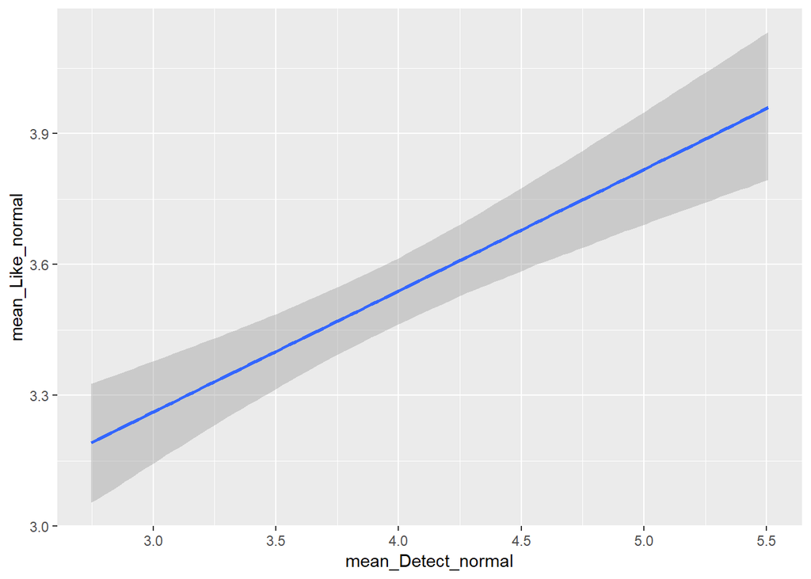

```r
marginal_effects(brm_normal_gaussian)
```

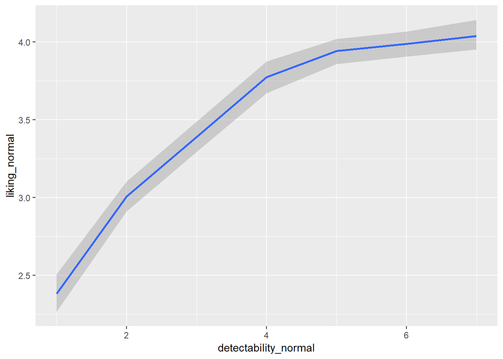

```r
marginal_effects(brm_normal_cumulative)
```

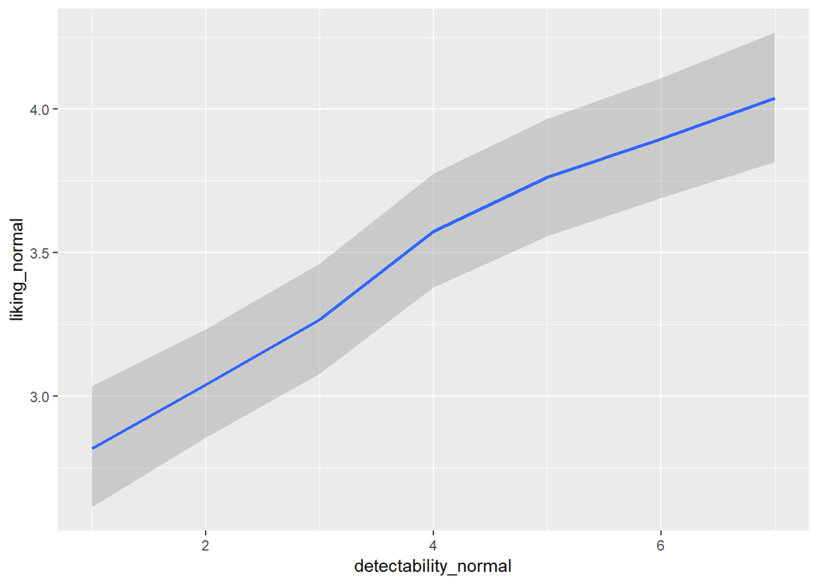

```r
marginal_effects(brm_normal_mixed)
```

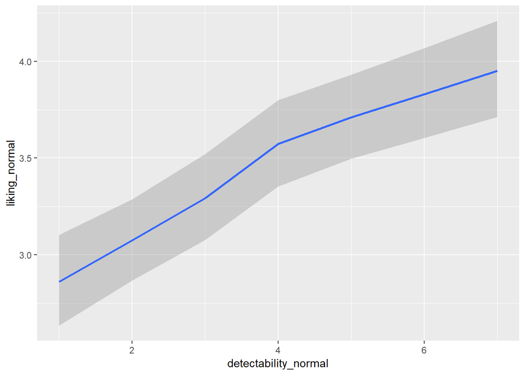

```r
marginal_effects(brm_normal_mixed2)
```